# Math216 Final Project

Andrew Kazal

12/12/2018

# Predicting English Premier League Player Performance

### An Analysis Using Player-Level Fantasy Data

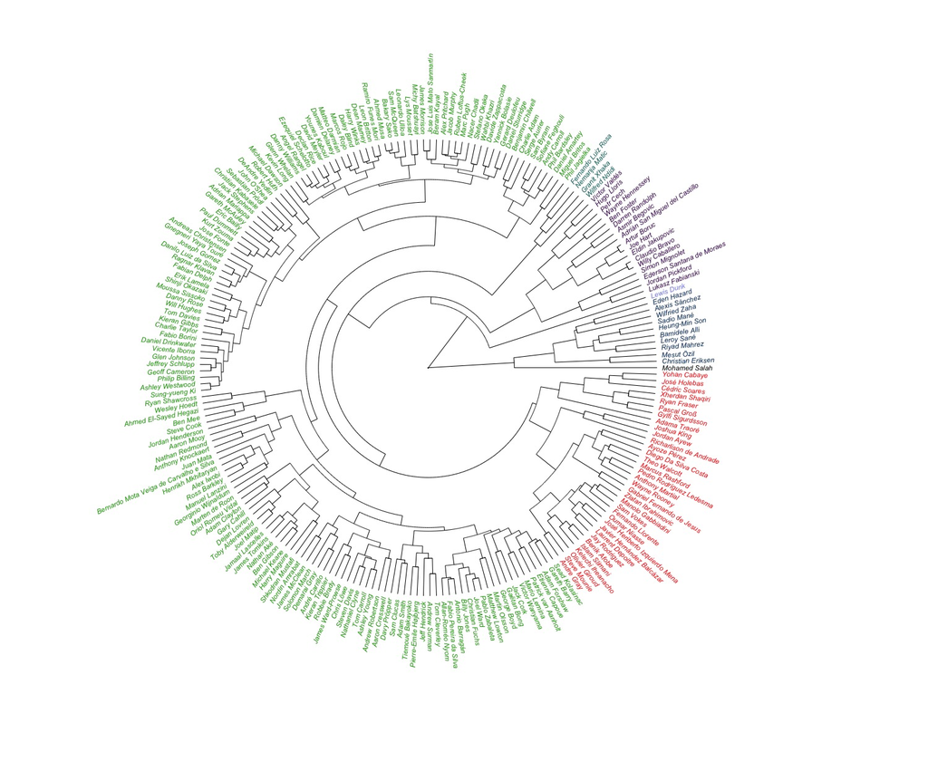

Figure 1. Hierarchical clustering dendrogram made using half of players with more than 20 games played - 7 clusters.

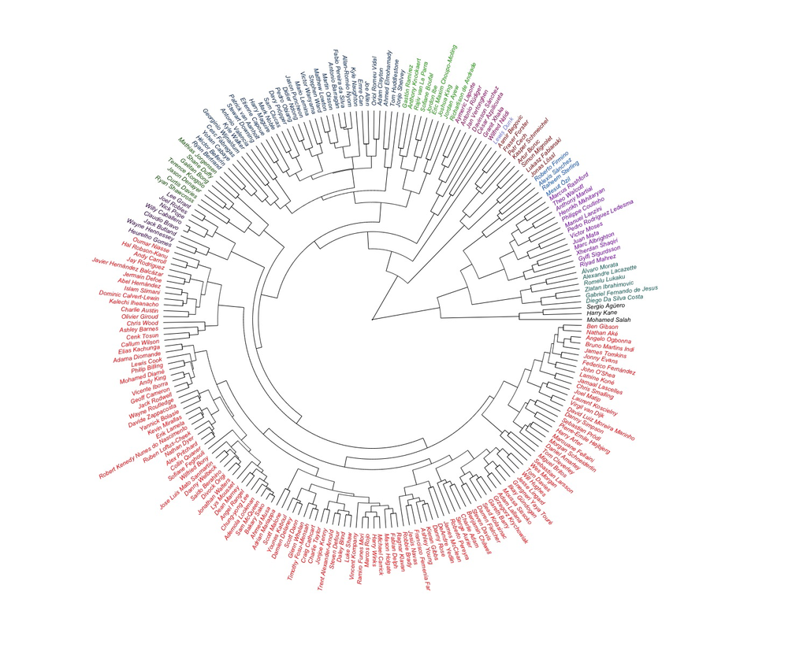

Figure 2. Hierarchical clustering dendrogram made using half of players with more than 20 games played - 12 clusters.

#### 1) Introduction

In the world of fantasy sports, the goal is always to place first. And the case of fantasy soccer in the Premier League is no exception. The difficulty of this task depends on the skill of other league competitors, the predictability of the sport, and a number of other factors. In order to succeed, it helps to have an awareness of or even expertise in the league. However, since fantasy sports are often more of a hobby than a means of making a living, participants are often irrational and uninformed. With this in mind, I set about constructing a data-driven analysis that might inform a participant’s decisions.  
The Fantasy Premier League system run by the Barclays Premier League tracks players and their respective statistics over the course of multiple seasons. These statistics are published on the Premier League’s website, and a github user published a scraped compilation from the 2016-2017 (2016), 2017-2018 (2017), and 2018-2019 (2018) seasons. Therefore, this data is publicly available in csv format. Only the first 12 weeks of the 2018-2019 season are present as this season is in progress.  
Each observation in this data set is a player in a game week in a given year. For example, one entry is Mohamed Salah’s statistics for game week one in 2017. In total, there are 52614 observations of player-year-game week combinations. Included in this data set are many basic offensive and defensive statistics for each player as well as match information. Some example player statistics are: minutes played; assists; goals; attempted passes; dribbles; saves; and clearances, blocks, and interceptions. The Fantasy Premier League uses these statistics to assign a player a total number of points earned for each game week. This point total is calculated differently for each position. For example, a goal is worth more when scored by a defender than when scored by a forward. These point totals generally reflect the player’s performance in that game week, with higher points representing a better performance and lower points representing a worse performance.  
As a fantasy participant, predicting future total points would be hugely valuable in choosing a team and deciding which players to transfer in or out of one’s team. Thus, using the data set described above, I asked: is it possible to predict a player’s points in the upcoming game week using that player’s statistics from the previous game week? I attempt to answer that question in the following analysis.

#### 2) Methods

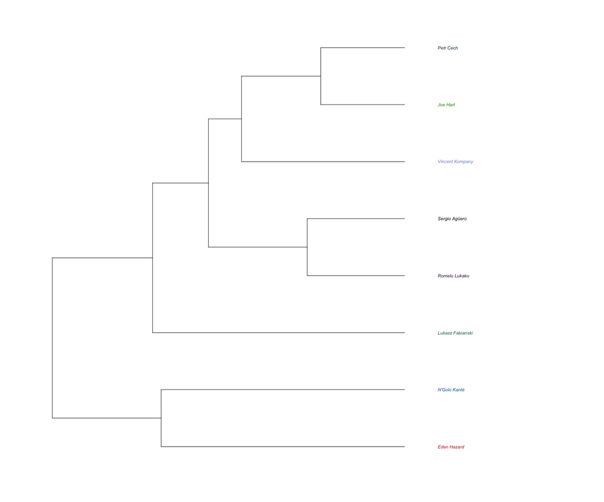

Figure 3. First attempt at hierarchical clustering shown in a dendrogram made using mean statistics over all observations for a small selection of popular players.

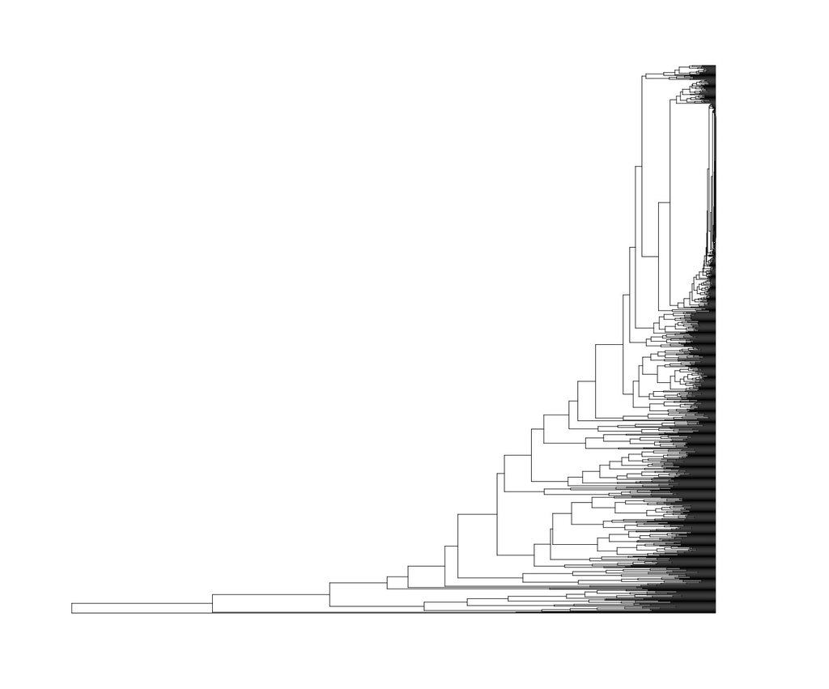

Figure 4. Second attempt at hierarchical clustering shown in a dendrogram made using mean statistics over all observations for each player.